# Springboard’s Introduction to Data Science (Capstone Project) - Predicting Semiconductor Wafer Failures by Modeling Equipment Sensor Data

### 4.4.3 Threshold Tuning

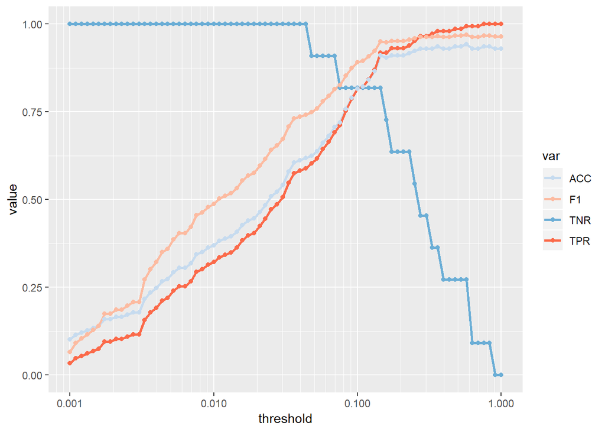

Fig. 4.6: TPR, TNR, accuracy and F1 score vs. threshold.

Setting the threshold to 0.1 increases TNR to 0.8182, but decreases accuracy to 0.8153, F1 score to 0.8914 and TPR to 0.8151.

```
## Confusion Matrix and Statistics
##
##           Reference
## Prediction   0   1
##          0 119   2
##          1  27   9
##
##                Accuracy : 0.8153
##                  95% CI : (0.7456, 0.8727)
##     No Information Rate : 0.9299
##     P-Value [Acc > NIR] : 1
##
##                   Kappa : 0.3088
##  Mcnemar's Test P-Value : 8.324e-06
##
##             Sensitivity : 0.8151
##             Specificity : 0.8182
##          Pos Pred Value : 0.9835
##          Neg Pred Value : 0.2500
##              Prevalence : 0.9299
##          Detection Rate : 0.7580
##    Detection Prevalence : 0.7707
##       Balanced Accuracy : 0.8166
##
##        'Positive' Class : 0
##
```

### 4.4.4 Test

Test data results below show accuracy = 0.5128, F1 score = 0.6481, TPR = 0.4795 and TNR = 1.

```
## Confusion Matrix and Statistics
##
##           Reference
## Prediction  0  1
##          0 35  0
##          1 38  5
##
##                Accuracy : 0.5128
##                  95% CI : (0.3969, 0.6277)
##     No Information Rate : 0.9359
##     P-Value [Acc > NIR] : 1
##
##                   Kappa : 0.1056
##  Mcnemar's Test P-Value : 1.947e-09
##
##             Sensitivity : 0.4795
##             Specificity : 1.0000
##          Pos Pred Value : 1.0000
##          Neg Pred Value : 0.1163
##              Prevalence : 0.9359
##          Detection Rate : 0.4487
##    Detection Prevalence : 0.4487
##       Balanced Accuracy : 0.7397
##
##        'Positive' Class : 0
##
```

### 4.4.5 Summary

Table 4.3: Iterated logistic model summary.

| Model | Stage | TPR | TNR | Accuracy | F1-Score |
| --- | --- | --- | --- | --- | --- |
| iterated logistic | train | 0.9855 | 0.0455 | 0.9234 | 0.9601 |
| iterated logistic | tune | 0.8151 | 0.8182 | 0.8153 | 0.8914 |
| iterated logistic | test | 0.4795 | 1.0000 | 0.5128 | 0.6481 |

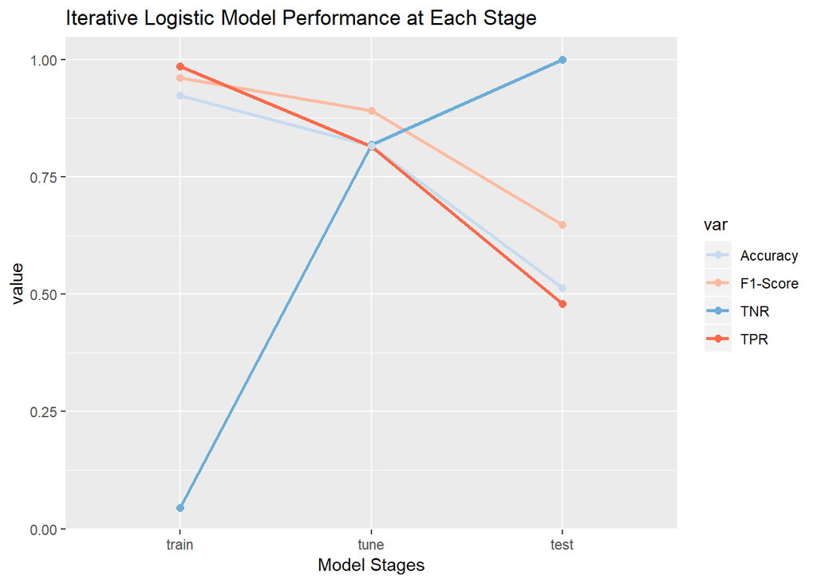

Fig. 4.7: TPR, TNR, accuracy and F1 score vs. model fit stage

## 4.5 Class Rebalancing

A notable characteristic of the SECOM dataset mentioned at the outset of this project was the relatively few failure observations relative to passing observations (> 10:1). This dataset characteristic is known as an imbalanced classification problem and is problematic in machine learning algorithms since they’re designed to improve accuracy by minimizing fit error but cannot account for the class distribution. This tends to lead to bias toward the majority class and yields an accurate model with poor discernability to predict minority class observations. Dealing with imbalanced datasets entails strategies for balancing classes in the training data prior to using any machine learning algorithm. One strategy is to use sampling techniques to balance the original dataset. There are a number of resampling techniques in the literature including:

- Undersampling - Randomly removing majority class observations until the classes are balanced.
- Oversampling - Randomly replicate minority class observations until the classes are balanced.
- Informed Oversampling: Synthetic Minority Oversampling Technique (SMOTE) - A subset of minority class data is used to derive, or synthesize new observations.
- Modified Synthetic Minority Oversampling Technique (MSMOTE) - Builds on SMOTE by taking the underlying minority class distribution into account to minimize the effects of noise in the data and blurring of class boundaries.

Another approach to dealing with the class imbalance entails algorithm ensemble techniques to improve the performance of single classifiers of existing classification algorithms. Some examples of techniques in the literature are listed below. These techniques are advanced and a little beyond scope but would be of interest for future development work.

- Bootstrap Aggregating (“Bagging”)
- Boosting-Based
- Adaptive Boosting
- Gradient Tree Boosting
- XG Boost

For this work the number of failure observations is too small to consider undersampling, so oversampling is required. SMOTE was chosen as it helps mitigate over fitting errors associated with using multiple copies of identical observations as occurs in statistical oversampling, and the technique is readily implemented using the [**smotefamily package**](https://cran.r-project.org/web/packages/smotefamily/index.html). Table 4.4 below shows the original and balanced training data results. In order to maintain the predictive integrity of the tuning and test datasets, those datasets are not rebalanced. Fig. 4.8 overlays training dataset density plots of failure observations before and after rebalancing for a sample of feature distributions and shows that the synthesized data characteristics are consistent with the original as desired.

Table 4.4: Taining dataset summary before and after rebalaning.

|  | Observations | Pass | Fail |
| --- | --- | --- | --- |
| Original | 1332 | 1244 | 88 |
| Balanced | 2476 | 1244 | 1232 |

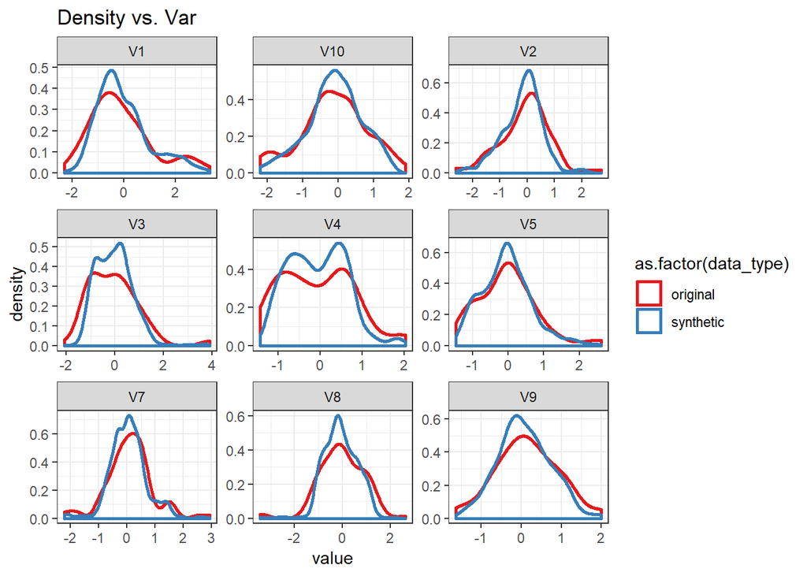

Fig. 4.8: Example distributions comparing original and synthesized of failure observation distributions.

## 4.6 Iterative Logistic Regression Revisited

### 4.6.1 Training

Now that the training dataset is balanced the iterative logistic model is refit. Please refer to Appendix B for detailed model output. The AIC score of 457 is a further improvement with accuracy = 0.998, F1 score = 0.998, TPR = 0.996 and TNR = 1. Confusion matrix results and a plot of most to least significant model features are shown below. The number of significant features has substantially increased as shown in Fig. 4.9.

```
## Confusion Matrix and Statistics
##
##           Reference
## Prediction    0    1
##          0 1239    0
##          1    5 1232
##
##                Accuracy : 0.998
##                  95% CI : (0.9953, 0.9993)
##     No Information Rate : 0.5024
##     P-Value [Acc > NIR] : < 2e-16
##
##                   Kappa : 0.996
##  Mcnemar's Test P-Value : 0.07364
##
##             Sensitivity : 0.9960
##             Specificity : 1.0000
##          Pos Pred Value : 1.0000
##          Neg Pred Value : 0.9960
##              Prevalence : 0.5024
##          Detection Rate : 0.5004
##    Detection Prevalence : 0.5004
##       Balanced Accuracy : 0.9980
##
##        'Positive' Class : 0
##
```

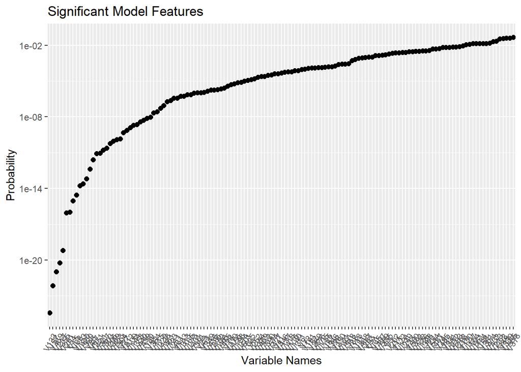

Fig. 4.9: Significant model features after class balancing, ordered most to least signicant from left to right.

```
## Confusion Matrix and Statistics
##
##           Reference
## Prediction   0   1
##          0 120   4
##          1  26   7
##
##                Accuracy : 0.8089
##                  95% CI : (0.7386, 0.8672)
##     No Information Rate : 0.9299
##     P-Value [Acc > NIR] : 1.000000
##
##                   Kappa : 0.2381
##  Mcnemar's Test P-Value : 0.000126
##
##             Sensitivity : 0.8219
##             Specificity : 0.6364
##          Pos Pred Value : 0.9677
##          Neg Pred Value : 0.2121
##              Prevalence : 0.9299
##          Detection Rate : 0.7643
##    Detection Prevalence : 0.7898
##       Balanced Accuracy : 0.7291
##
##        'Positive' Class : 0
##
```

### 4.6.2 ROC Analysis

The new AUC = 0.8207 is a decreased showing poorer pass/fail discernability. The ROC curve is plotted below.

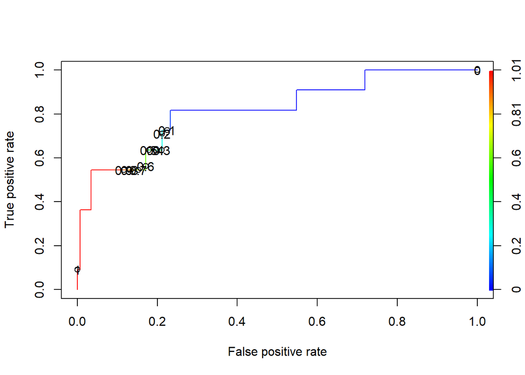

Fig. 4.10: Receiver operating characteristic (ROC) curve for class balanced, iterative logistic model fit.

### 4.6.3 Threshold Tuning

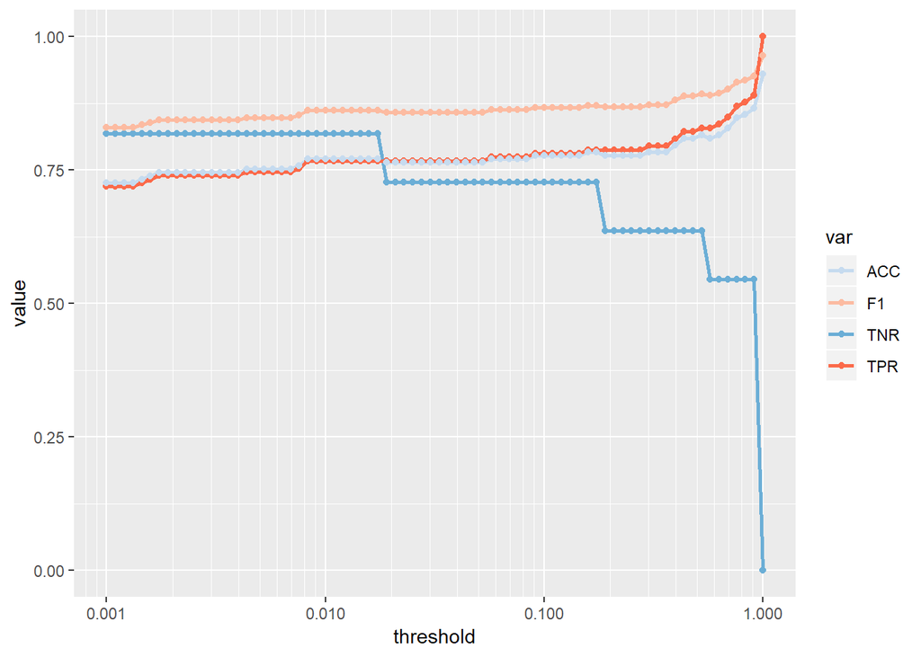

Fig. 4.11: TPR, TNR, accuracy and F1 score vs. threshold.

Setting the threshold to 0.0174 increases TNR to 0.8182, but decreases accuracy to 0.7707 and TPR to 0.7671. F1 score = 0.8615.

```
## Confusion Matrix and Statistics
##
##           Reference
## Prediction   0   1
##          0 112   2
##          1  34   9
##
##                Accuracy : 0.7707
##                  95% CI : (0.697, 0.8339)
##     No Information Rate : 0.9299
##     P-Value [Acc > NIR] : 1
##
##                   Kappa : 0.2496
##  Mcnemar's Test P-Value : 2.383e-07
##
##             Sensitivity : 0.7671
##             Specificity : 0.8182
##          Pos Pred Value : 0.9825
##          Neg Pred Value : 0.2093
##              Prevalence : 0.9299
##          Detection Rate : 0.7134
##    Detection Prevalence : 0.7261
##       Balanced Accuracy : 0.7927
##
##        'Positive' Class : 0
##
```

### 4.6.4 Test

Test data results below show accuracy = 0.859, TPR = 0.863, TNR = 0.8 and F1 score = 0.9197

```
## Confusion Matrix and Statistics
##
##           Reference
## Prediction  0  1
##          0 63  1
##          1 10  4
##
##                Accuracy : 0.859
##                  95% CI : (0.7617, 0.9274)
##     No Information Rate : 0.9359
##     P-Value [Acc > NIR] : 0.99604
##
##                   Kappa : 0.3607
##  Mcnemar's Test P-Value : 0.01586
##
##             Sensitivity : 0.8630
##             Specificity : 0.8000
##          Pos Pred Value : 0.9844
##          Neg Pred Value : 0.2857
##              Prevalence : 0.9359
##          Detection Rate : 0.8077
##    Detection Prevalence : 0.8205
##       Balanced Accuracy : 0.8315
##
##        'Positive' Class : 0
##
```

### 4.6.5 Summary

Table 4.5: Iterated logistic model summary.

| Model | Stage | TPR | TNR | Accuracy | F1-Score |
| --- | --- | --- | --- | --- | --- |
| iterated logistic (SMOTE) | train | 0.9960 | 1.0000 | 0.9980 | 0.9980 |
| iterated logistic (SMOTE) | tune | 0.7671 | 0.8182 | 0.7707 | 0.8615 |
| iterated logistic (SMOTE) | test | 0.8630 | 0.8000 | 0.8590 | 0.9197 |

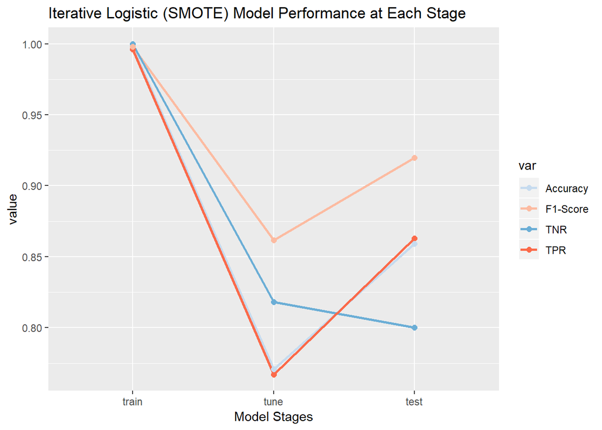

Fig. 4.12: TPR, TNR, accuracy and F1 score vs. model fit stage

## 4.7 Random Forest

In this last model a random forest classification fit is performed. In short, random forest is a machine learning technique which builds multiple decision trees and merges them together to obtain a more accurate and stable prediction. It’s very susceptible to over fitting due to class imbalance which was a primary reason for rebalancing the SECOM dataset originally. The [**randomForest package**](https://cran.r-project.org/web/packages/randomForest/index.html) was used for this project.

### 4.7.1 Parameter Analysis

The random forest model contains a number of tuning variables to tweak the model of which the primary ones considered here were ‘cutoff’, ‘ntree’, ‘mtry’, ‘nodesize’ and ‘maxit’. The approach taken was to build a parameter grid to measure the model sensitivity for TPR, TNR, accuracy and F1 score. Initially max iterations (maxit) was found to be insensitive so the remaining results assume maxit = 10 for speed sake. The plots below show TPR, TNR, accuracy and F1 score versus cutoff with ntree as the parameter where ntree is the number of trees to grow in the forest for the training data. The ‘cutoff’ parameter functions similar to the threshold for earlier logistic models. The plots are faceted by ‘mtry’, the number of variables randomly sampled as candidates at each split, and ‘nodesize’, the minimum size of terminal nodes. Results for the training data are shown below where it’s seen that the number of trees (ntree) has little effect for ntree > 100 due to the ‘cutoff’ settings restricting over fitting. The training results seem to suggest a wide range of values for ‘cutoff’, ‘mtry’ and ‘nodesize’ for obtaining a perfect fit.

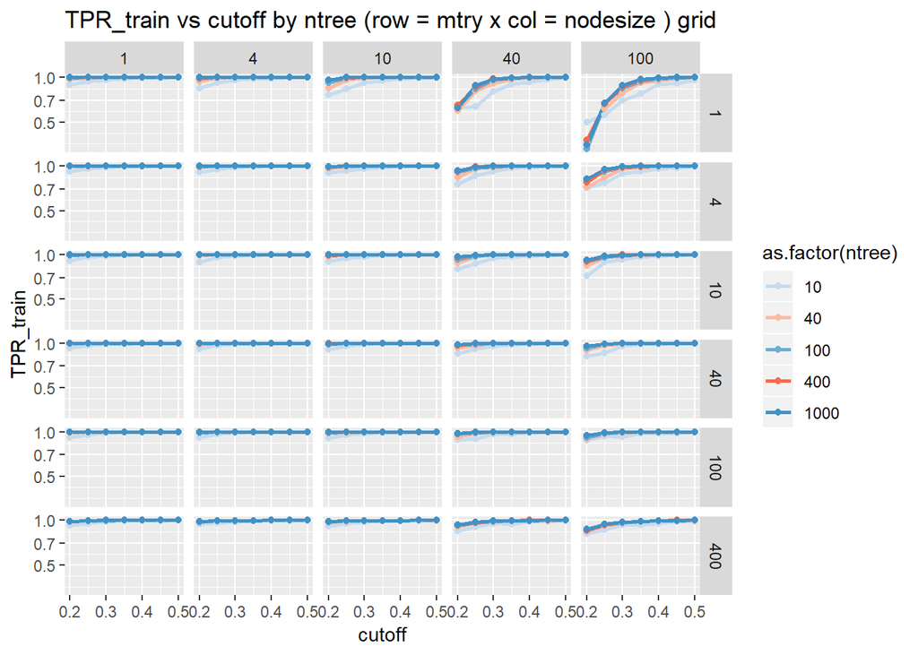

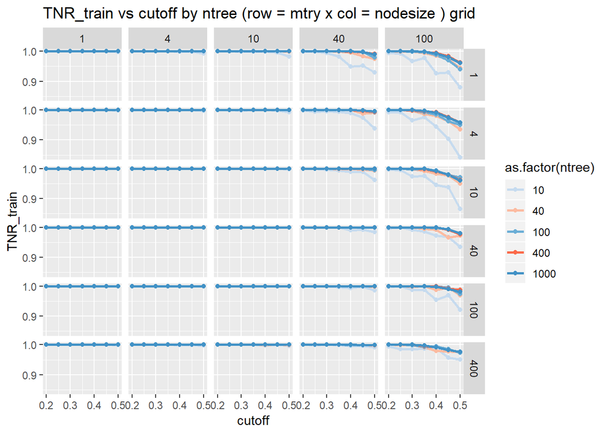

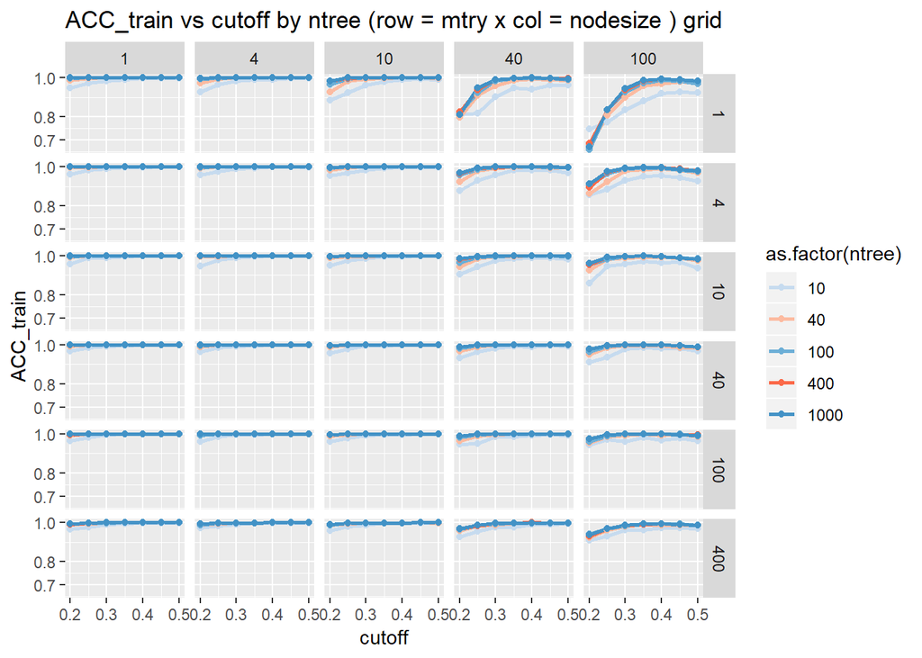

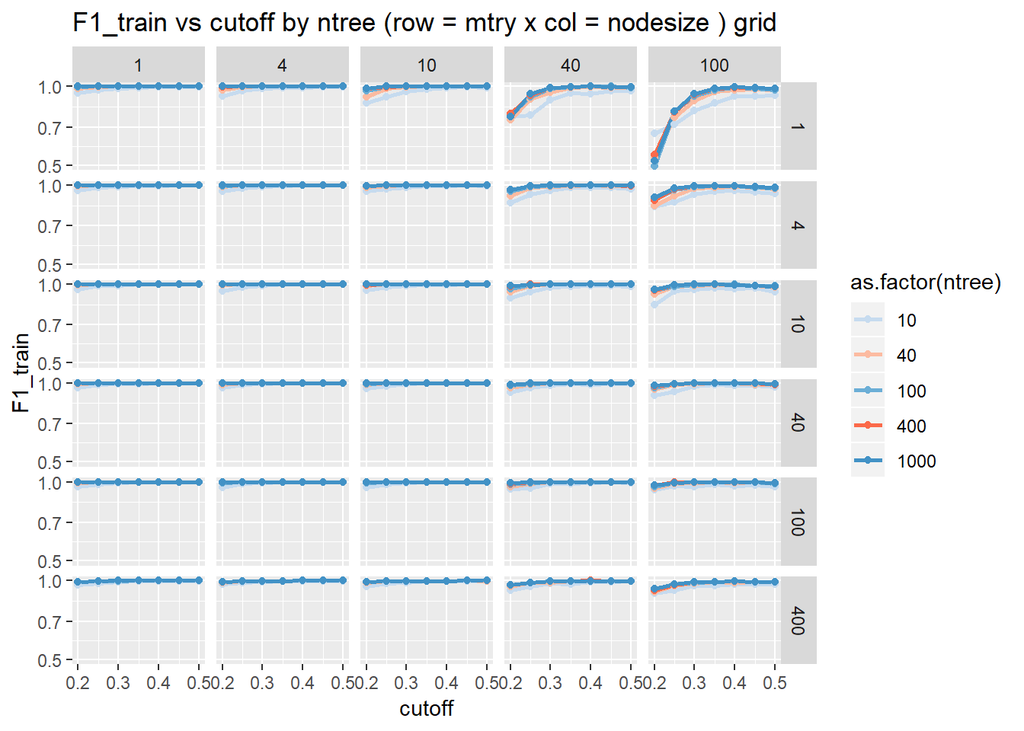

Fig. 4.13 Training data True Positive Rate (TPR), True Negative Rate (TNR), Accuracy (ACC) and F1 Score (F1) vs. cutoff coarse grid plots.

### 4.7.2 Parameter Optimization

Results for the tuning dataset in Fig. 4.14 below exhibit significantly more dependence on ‘cutoff’, ‘mtry’ and ‘nodesize’. The most significant dependence change is with TNR which is now inversely proportional to ‘cutoff’ and significantly decreases the model’s efficacy. Similar to the method used to identify the optimal threshold value for the earlier logistic models, Fig. 4.15 shows the relationship for TNR, TPR, accuracy and F1 score versus ‘cutoff’ overlaid on the same plots and faceted again by ‘mtry’ and ‘nodesize’. Using the magnified plot on the right side, the optimal model parameters maximize the intersection of these 4 measures which are listed below.

- nodesize = 1
- ntree = 400
- maxit = 10
- mtry = 40
- cutoff = 0.25

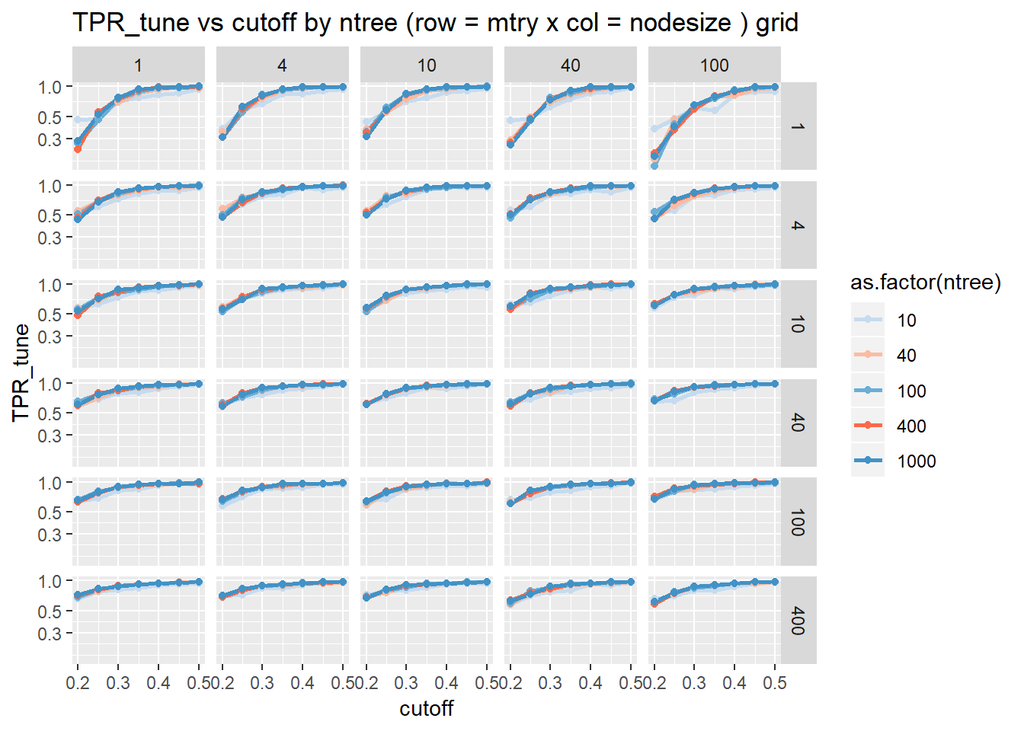

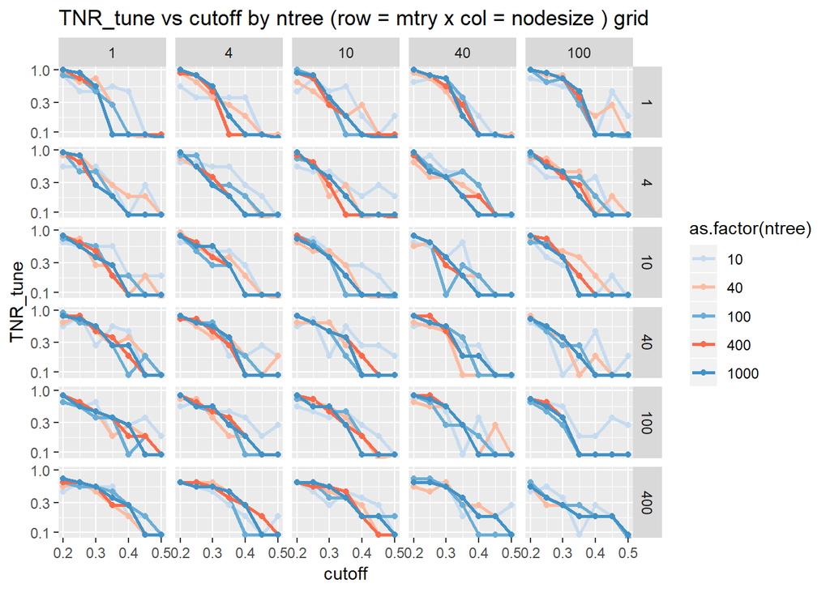

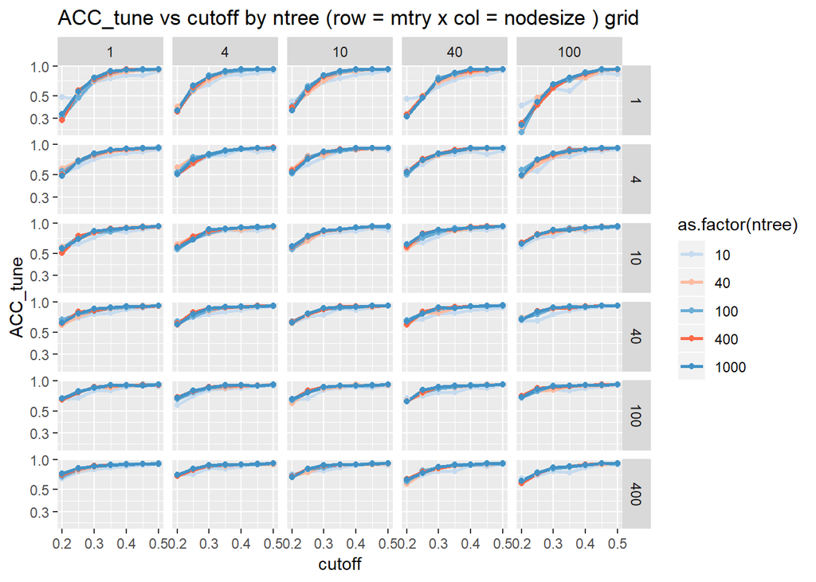

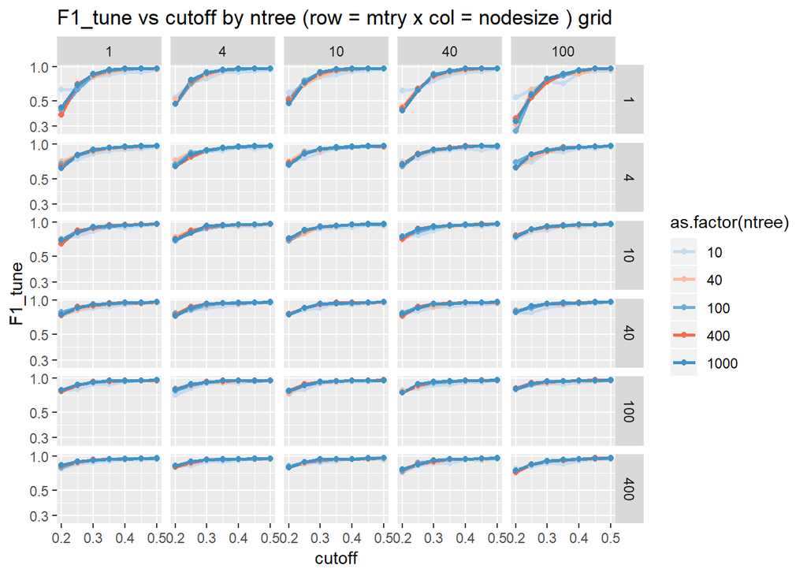

Fig. 4.14 Tuning data True Positive Rate (TPR), True Negative Rate (TNR), Accuracy (ACC) and F1 Score (F1) vs. cutoff coarse grid plots.

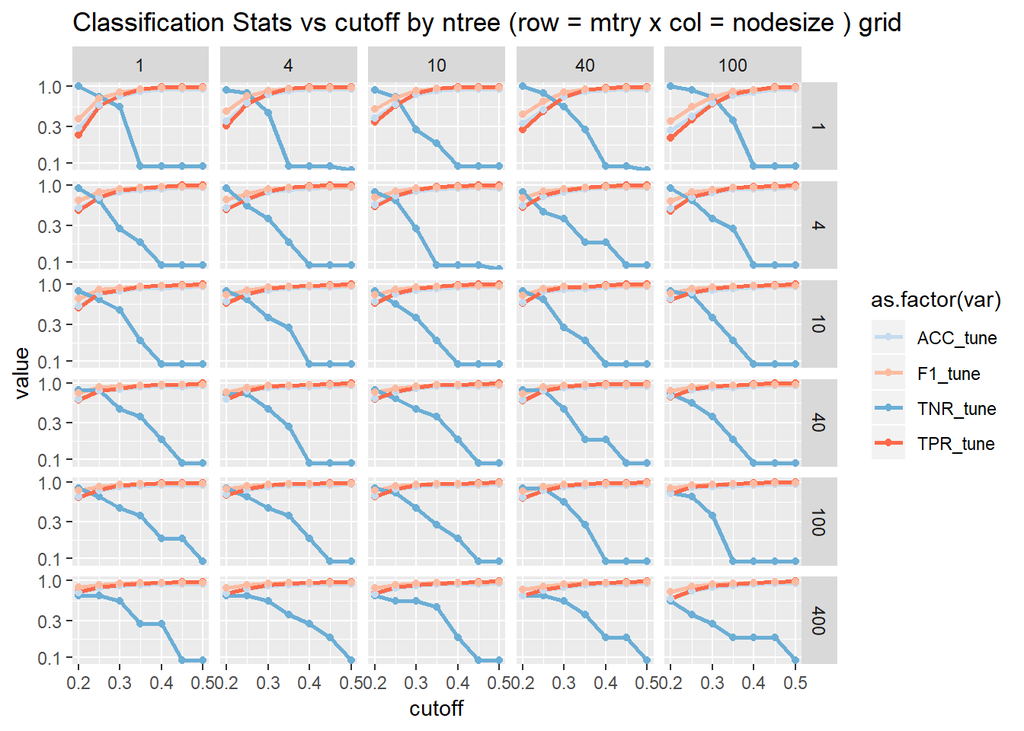

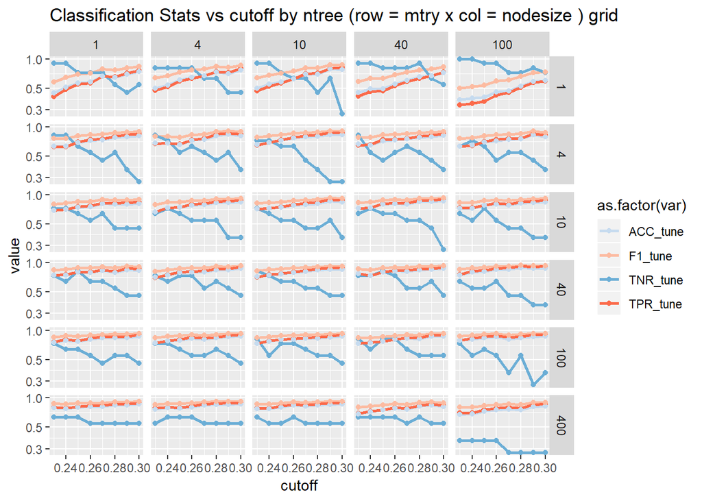

Fig. 4.15 Tuning data True Positive Rate (TPR), True Negative Rate (TNR), Accuracy (ACC) and F1 Score (F1) vs. cutoff overlay plots.

### 4.7.3 Optimum Model (Training Data)

Training data results below show accuracy = 1, TPR = 1, TNR = 1 and F1 score = 1

```
## Confusion Matrix and Statistics
##
##           Reference
## Prediction    0    1
##          0 1244    0
##          1    0 1232
##
##                Accuracy : 1
##                  95% CI : (0.9985, 1)
##     No Information Rate : 0.5024
##     P-Value [Acc > NIR] : < 2.2e-16
##
##                   Kappa : 1
##  Mcnemar's Test P-Value : NA
##
##             Sensitivity : 1.0000
##             Specificity : 1.0000
##          Pos Pred Value : 1.0000
##          Neg Pred Value : 1.0000
##              Prevalence : 0.5024
##          Detection Rate : 0.5024
##    Detection Prevalence : 0.5024
##       Balanced Accuracy : 1.0000
##
##        'Positive' Class : 0
##
```

### 4.7.4 Optimum Model (Tuning Data)

Tuning data results below show accuracy = 0.7962, TPR = 0.7945, TNR = 0.8182 and F1 score = 0.8788

```
## Confusion Matrix and Statistics
##
##           Reference
## Prediction   0   1
##          0 116   2
##          1  30   9
##
##                Accuracy : 0.7962
##                  95% CI : (0.7246, 0.8562)
##     No Information Rate : 0.9299
##     P-Value [Acc > NIR] : 1
##
##                   Kappa : 0.2815
##  Mcnemar's Test P-Value : 1.815e-06
##
##             Sensitivity : 0.7945
##             Specificity : 0.8182
##          Pos Pred Value : 0.9831
##          Neg Pred Value : 0.2308
##              Prevalence : 0.9299
##          Detection Rate : 0.7389
##    Detection Prevalence : 0.7516
##       Balanced Accuracy : 0.8064
##
##        'Positive' Class : 0
##
```

### 4.7.5 Optimum Model (Test Data)

Test data results below show accuracy = 0.7821, TPR = 0.7808, TNR = 0.8 and F1 score = 0.8702

```
## Confusion Matrix and Statistics
##
##           Reference
## Prediction  0  1
##          0 57  1
##          1 16  4
##
##                Accuracy : 0.7821
##                  95% CI : (0.6741, 0.8676)
##     No Information Rate : 0.9359
##     P-Value [Acc > NIR] : 0.999998
##
##                   Kappa : 0.2423
##  Mcnemar's Test P-Value : 0.000685
##
##             Sensitivity : 0.7808
##             Specificity : 0.8000
##          Pos Pred Value : 0.9828
##          Neg Pred Value : 0.2000
##              Prevalence : 0.9359
##          Detection Rate : 0.7308
##    Detection Prevalence : 0.7436
##       Balanced Accuracy : 0.7904
##
##        'Positive' Class : 0
##
```

### 4.7.6 Optimum Model (Summary)

Table 4.6: Random Forest model summary.

| Model | Stage | TPR | TNR | Accuracy | F1-Score |
| --- | --- | --- | --- | --- | --- |
| random forest | train | 1.0000 | 1.0000 | 1.0000 | 1.0000 |
| random forest | tune | 0.7945 | 0.8182 | 0.7962 | 0.8788 |
| random forest | test | 0.7808 | 0.8000 | 0.7821 | 0.8702 |

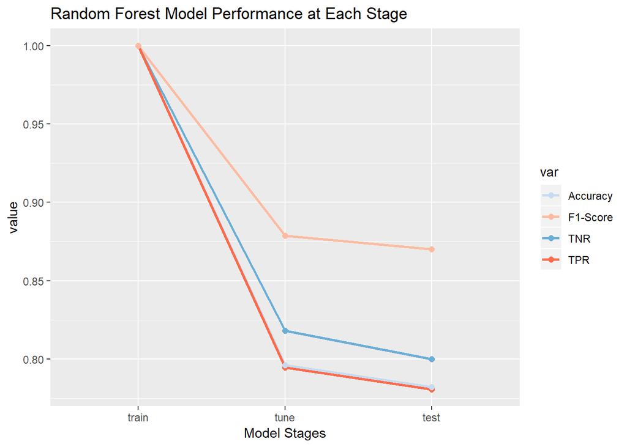

Fig. 4.16: TPR, TNR, accuracy and F1 score vs. model fit stage

## 4.8 Model Summaries

Model summaries are provide below and grouped by the modeling stage, either train, tune or test. The test stage is considered the final model performance.

### 4.8.1 Training Summary

Table 4.7: Model training summary.

| Model | Stage | TPR | TNR | Accuracy | F1-Score |
| --- | --- | --- | --- | --- | --- |
| logistic | train | 0.9992 | 0.8977 | 0.9925 | 0.9960 |
| iterated logistic | train | 0.9855 | 0.0455 | 0.9234 | 0.9601 |
| iterated logistic (SMOTE) | train | 0.9960 | 1.0000 | 0.9980 | 0.9980 |
| random forest | train | 1.0000 | 1.0000 | 1.0000 | 1.0000 |

### 4.8.2 Tuning Summary

Table 4.8 summarizes TPR, TNR, accuracy and F1 score for the models considered in this project at tuning stage. All model performances decay nearly the same amount but results suggest that the iterated logistic model provides the best overall performance with random forest right behind.

Table 4.8: Model tuning summary.

| Model | Stage | TPR | TNR | Accuracy | F1-Score |
| --- | --- | --- | --- | --- | --- |
| logistic | tune | 0.7877 | 0.8182 | 0.7898 | 0.8745 |
| iterated logistic | tune | 0.8151 | 0.8182 | 0.8153 | 0.8914 |
| iterated logistic (SMOTE) | tune | 0.7671 | 0.8182 | 0.7707 | 0.8615 |
| random forest | tune | 0.7945 | 0.8182 | 0.7962 | 0.8788 |

### 4.8.3 Final Test Summary

Table 4.9 summarizes TPR, TNR, accuracy and F1 score for the models considered in this project at the final testing stage. There was a notable shift in the iterated logistic model due to threshold sensitivity. The remaining three models remained comparably stable. The baseline logistic and class balanced iterative logistic model appear to perform identically and exhibit ~10% overall performance boost compared with tuning data results. Between these two the balanced iterative logistic model is preferred as it has fewer features and the lower AIC score. However, the random forest model results are not far behind and in fact have less variability comparing tuning with test results. Random forest is therefore a very good alternative model.

Table 4.9: Model final test summary.

| Model | Stage | TPR | TNR | Accuracy | F1-Score |
| --- | --- | --- | --- | --- | --- |
| logistic | test | 0.8630 | 0.8 | 0.8590 | 0.9197 |
| iterated logistic | test | 0.4795 | 1.0 | 0.5128 | 0.6481 |
| iterated logistic (SMOTE) | test | 0.8630 | 0.8 | 0.8590 | 0.9197 |
| random forest | test | 0.7808 | 0.8 | 0.7821 | 0.8702 |

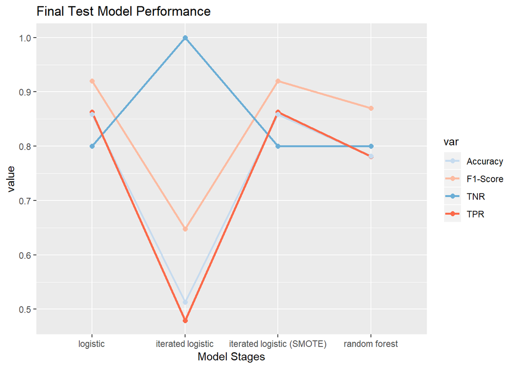

Fig. 4.17: TPR, TNR, accuracy and F1 score vs. model.

# 5 Conclusions and Future Recommendations

## 5.1 Conclusions

- The baseline logistic model yielded an accuracy of TPR = 0.863, TNR = 0.8, 85.9%, F1 score = 91.97% but used all 414 features.
- The more efficient model with this same predictive power as the baseline model was the iterated logistic model applied to class balanced data which yielded an accuracy of TPR = 0.863, TNR = 0.8, 85.9%, F1 score = 91.97% and used only 139 features.
- The random forest model performance was slightly lower than the above logistic models, but the stability in the model from tuning to test suggest the model is a very good runner-up.

## 5.2 Future Recommendations

- The power and utility of random forest was evident in the initial training results, but even using class balanced data and optimizing on the ‘cutoff’ parameter, the model still suffered from over fitting. The next step for this dataset is to apply algorithm ensemble techniques mentioned earlier for addressing class imbalance. In particular XG Boost, an extreme gradient boost algorithm based on trees, is of interest due to its out-of-the-box performance, versatility in tuning parameters and parallel processing capability.
- The biggest problem with the current dataset was not having any information on the sensor origins. If the physical meaning of the measurements were available it would be possible to perform feature engineering to properly transform the data based on the underlying physical meaning.
- The pass/fail criteria for the current dataset is another unknown. If this criteria was available it would provide additional feature engineering support or suggest additional sub classifications, meaning there may be more than one failure criteria at work which affects which sensors are more relevant for each failure type. The current model assumes the same sensors are important for all failures which is not correct.

# 6 Appendix A

# 7 Appendix B

## 7.1 Baseline Logistic Regression Model Results

```
##
## Call:
## bayesglm(formula = Status ~ ., family = "binomial", data = trainData,
##     maxit = 200)
##
## Deviance Residuals:
##      Min        1Q    Median        3Q       Max
## -1.28232  -0.12155  -0.02053  -0.00224   1.99066
##
## Coefficients:
##               Estimate Std. Error z value Pr(>|z|)
## (Intercept) -7.0626331  0.8107630  -8.711  < 2e-16 ***
## V1          -0.2609767  0.2954170  -0.883  0.37701
## V2          -0.2903392  0.2861980  -1.014  0.31036
## V3          -0.3216495  0.4475332  -0.719  0.47232
## V4          -0.0416842  0.5799741  -0.072  0.94270
## V5           0.0657829  0.4475007   0.147  0.88313
## V7          -0.1858288  0.4590828  -0.405  0.68564
## V8           0.4945563  0.4419088   1.119  0.26308
## V9          -0.0367219  0.3390667  -0.108  0.91376
## V10         -0.1767529  0.2893000  -0.611  0.54122
## V11         -0.3726488  0.2985720  -1.248  0.21199
## V12          0.0418189  0.6990001   0.060  0.95229
## V13         -0.0990936  0.7973638  -0.124  0.90110
## V15         -1.4565009  0.6830570  -2.132  0.03298 *
## V16         -0.0338828  0.3488698  -0.097  0.92263
## V17          0.1347087  0.3175562   0.424  0.67142
## V18         -0.1564667  0.7916692  -0.198  0.84333
## V19         -0.0822949  0.7228763  -0.114  0.90936
## V20          0.5903551  0.7538726   0.783  0.43357
## V21          0.2227250  0.3419533   0.651  0.51483
## V22          0.1735002  0.5114352   0.339  0.73443
## V23         -0.1982178  0.5508594  -0.360  0.71897
## V24          0.2420678  0.3688182   0.656  0.51161
## V25         -0.0959748  0.3081243  -0.311  0.75544
## V26          0.4679630  0.8898115   0.526  0.59895
## V27         -0.8255856  0.6849044  -1.205  0.22805
## V28          0.3489043  0.8124104   0.429  0.66758
## V29         -0.7793114  0.4784178  -1.629  0.10333
## V30          0.5362285  0.6003993   0.893  0.37179
```

[output cut: 381 more lines]

```
## V586        -0.0841964  0.7922007  -0.106  0.91536
## V587        -0.2773683  0.4996178  -0.555  0.57878
## V588         0.4648039  0.7222175   0.644  0.51985
## V589         0.2610280  0.6882760   0.379  0.70450
## V590        -0.6848704  0.6098317  -1.123  0.26142
## ---
## Signif. codes:  0 '***' 0.001 '**' 0.01 '*' 0.05 '.' 0.1 ' ' 1
##
## (Dispersion parameter for binomial family taken to be 1)
##
##     Null deviance: 648.26  on 1331  degrees of freedom
## Residual deviance: 118.71  on  917  degrees of freedom
## AIC: 948.71
##
## Number of Fisher Scoring iterations: 41
```

## 7.2 Iterative Logistic Regression Model Results

```
##
## Call:
## bayesglm(formula = Status ~ ., family = "binomial", data = trainData,
##     maxit = 200)
##
## Deviance Residuals:
##      Min        1Q    Median        3Q       Max
## -1.56392  -0.33293  -0.19485  -0.09861   3.01216
##
## Coefficients:
##             Estimate Std. Error z value Pr(>|z|)
## (Intercept) -3.55622    0.21713 -16.378  < 2e-16 ***
## V15         -0.34637    0.13397  -2.585 0.009729 **
## V23         -0.23428    0.09679  -2.421 0.015497 *
## V54         -0.51206    0.23218  -2.205 0.027421 *
## V57          1.15227    0.26356   4.372 1.23e-05 ***
## V63         -0.86547    0.22644  -3.822 0.000132 ***
## V67          0.77974    0.27749   2.810 0.004955 **
## V100         0.27718    0.09772   2.836 0.004563 **
## V103        -0.28223    0.12166  -2.320 0.020345 *
## V123        -0.58493    0.16876  -3.466 0.000528 ***
## V130         0.41991    0.17084   2.458 0.013974 *
## V133        -0.66215    0.15019  -4.409 1.04e-05 ***
## V134         0.31229    0.13926   2.243 0.024926 *
## V153         0.24604    0.11104   2.216 0.026704 *
## V206         0.44612    0.14326   3.114 0.001845 **
## V217         1.13694    0.41439   2.744 0.006076 **
## V282        -0.39938    0.13807  -2.893 0.003821 **
## V303         0.33562    0.13175   2.547 0.010854 *
## V320         0.29149    0.14497   2.011 0.044350 *
## V334         0.58583    0.15626   3.749 0.000177 ***
## V355        -1.18383    0.42903  -2.759 0.005793 **
## V420        -0.26984    0.12739  -2.118 0.034157 *
## V425        -0.40300    0.16584  -2.430 0.015099 *
## V469        -0.62795    0.13074  -4.803 1.56e-06 ***
## V483         0.26005    0.12377   2.101 0.035630 *
## V512         0.25882    0.12201   2.121 0.033904 *
## V542         0.36320    0.12448   2.918 0.003527 **
## V588         0.50233    0.15147   3.316 0.000912 ***
## V590        -0.34552    0.15839  -2.181 0.029153 *
## ---
## Signif. codes:  0 '***' 0.001 '**' 0.01 '*' 0.05 '.' 0.1 ' ' 1
##
## (Dispersion parameter for binomial family taken to be 1)
##
##     Null deviance: 648.26  on 1331  degrees of freedom
## Residual deviance: 457.26  on 1303  degrees of freedom
## AIC: 515.26
##
## Number of Fisher Scoring iterations: 12
```

## 7.3 Class Balanced Iterative Logistic Regression Model Results

```
##
## Call:
## bayesglm(formula = Status ~ ., family = "binomial", data = trainData,
##     maxit = 200)
##
## Deviance Residuals:
##     Min       1Q   Median       3Q      Max
## -2.0305  -0.0014   0.0000   0.2014   0.7839
##
## Coefficients:
##             Estimate Std. Error z value Pr(>|z|)
## (Intercept) -11.5000     0.7084 -16.233  < 2e-16 ***
## V1           -0.9920     0.2283  -4.345 1.39e-05 ***
## V2           -0.7869     0.2014  -3.908 9.31e-05 ***
## V3           -0.7597     0.2449  -3.102 0.001922 **
## V10          -0.5801     0.2215  -2.619 0.008816 **
## V11          -0.6344     0.2080  -3.050 0.002290 **
## V15          -2.7126     0.3374  -8.040 8.99e-16 ***
## V20           1.8696     0.6425   2.910 0.003617 **
## V24           0.6414     0.2300   2.788 0.005299 **
## V26           3.6851     0.5083   7.250 4.16e-13 ***
## V27          -2.9022     0.4666  -6.220 4.97e-10 ***
## V29          -1.6331     0.3349  -4.876 1.08e-06 ***
## V33           0.5546     0.1857   2.986 0.002828 **
## V41          -0.8894     0.2171  -4.097 4.18e-05 ***
## V45          -1.0037     0.3144  -3.192 0.001411 **
## V52           0.8990     0.2342   3.839 0.000124 ***
## V54          -3.9522     0.4761  -8.301  < 2e-16 ***
## V57           6.1085     0.6203   9.848  < 2e-16 ***
## V58          -0.6196     0.2530  -2.449 0.014345 *
## V61           2.3491     0.4624   5.081 3.76e-07 ***
## V63          -3.2111     0.6598  -4.867 1.14e-06 ***
## V67           5.5902     0.7990   6.996 2.63e-12 ***
## V68           2.1104     0.2671   7.902 2.75e-15 ***
## V71          -2.3889     0.7291  -3.277 0.001050 **
## V72           1.0369     0.2667   3.888 0.000101 ***
## V76           1.0069     0.2692   3.741 0.000183 ***
## V78           0.9658     0.2090   4.621 3.82e-06 ***
## V81          -0.7890     0.2365  -3.336 0.000849 ***
## V85          -0.6350     0.2343  -2.710 0.006738 **
```

[output cut: 106 more lines]

```
## V561          0.5327     0.2168   2.457 0.013998 *
## V574         -1.1473     0.2761  -4.155 3.26e-05 ***
## V583          0.6014     0.2244   2.680 0.007356 **
## V585          0.4149     0.2025   2.048 0.040525 *
## V589          0.7340     0.2305   3.185 0.001450 **
## ---
## Signif. codes:  0 '***' 0.001 '**' 0.01 '*' 0.05 '.' 0.1 ' ' 1
##
## (Dispersion parameter for binomial family taken to be 1)
##
##     Null deviance: 3432.4  on 2475  degrees of freedom
## Residual deviance:  177.1  on 2336  degrees of freedom
## AIC: 457.1
##
## Number of Fisher Scoring iterations: 34
```